# 03_Full_code_notebook_TSF_project

### Triple Exponential Smoothing (Holt-winter's Model)

#### Auto-fit TES Model

```python
# Create Train and Test Dataset for TES
TES_train = train_dfs.copy()
TES_test = test_dfs.copy()

# Create Model using Holt-Winters'
TES_model = ExponentialSmoothing(TES_train['Sparkling'],trend='additive',seasonal='multiplicative',freq='M')
TES_model_fit = TES_model.fit()

# Show parameters
TES_model_fit.params
```

```
{'smoothing_level': 0.11133818361298699,
 'smoothing_trend': 0.049505131019509915,
 'smoothing_seasonal': 0.3620795793580111,
 'damping_trend': nan,
 'initial_level': 2356.4967888704355,
 'initial_trend': -10.187944726007238,
 'initial_seasons': array([0.71296382, 0.68242226, 0.90755008, 0.80515228, 0.65597218,
        0.65414505, 0.88617935, 1.13345121, 0.92046306, 1.21337874,
        1.87340336, 2.37811768]),
 'use_boxcox': False,
 'lamda': None,
 'remove_bias': False}
```

```python
# Create Prediction for Test Data using TES Model using Autofit parameters
TES_test['auto_predict'] = TES_model_fit.forecast(steps=len(TES_test))
TES_test.head()
```

| YearMonthDate | Sparkling | auto_predict |
| --- | --- | --- |
| 1991-01-31 | 1902 | 1587.4975 |
| 1991-02-28 | 2049 | 1356.3949 |
| 1991-03-31 | 1874 | 1762.9298 |
| 1991-04-30 | 1279 | 1656.1659 |
| 1991-05-31 | 1432 | 1542.0027 |

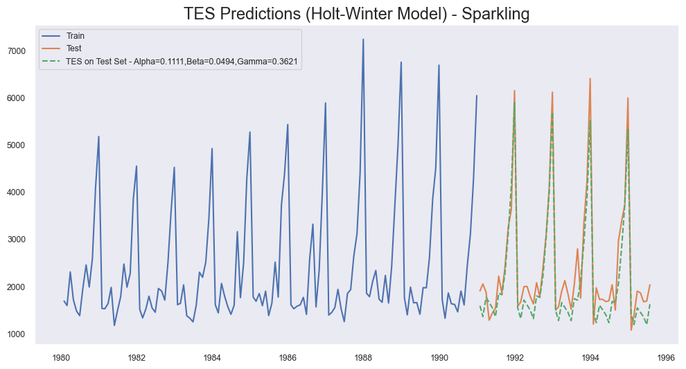

```python
## Plotting on both the Training and Test using autofit
plt.plot(TES_train['Sparkling'], label='Train')
plt.plot(TES_test['Sparkling'], label='Test')
plt.plot(TES_test['auto_predict'], linestyle='--', label='TES on Test Set - Alpha=0.1111,Beta=0.0494,Gamma=0.3621')
plt.title('TES Predictions (Holt-Winter Model) - Sparkling', fontsize=17)

plt.legend(loc='best')
plt.grid();
```

```python
# Calculate Root Mean Squared Error for Triple Exponential Smoothing (TES)
rmse_TES_test = metrics.mean_squared_error(TES_test['Sparkling'],TES_test['auto_predict'],squared=False)
print(f'For Triple Exponential Smoothing Model forecast on the Test Data,  RMSE is {rmse_TES_test: .4f}')
```

```
For Triple Exponential Smoothing Model forecast on the Test Data,  RMSE is  404.2868
```

```python
# Adding the new row to the DataFrame
resultsDf.loc['TES with Alpha=0.1111,Beta=0.0494,Gamma=0.3621'] = rmse_TES_test
resultsDf
```

|  | Test RMSE |
| --- | --- |
| Linear Regression | 1389.1352 |
| Naive Model | 3864.2794 |
| Simple Average Model | 1275.0818 |
| SES with Alpha=0.0395 | 1304.9274 |
| Tuned SES with Alpha=0.3 | 1935.5071 |
| DES with Alpha=0.668 and Beta=9.99e-05 | 2007.2385 |
| Tuned DES with Alpha=0.3 and Beta=0.3 | 18259.1107 |
| TES with Alpha=0.1111,Beta=0.0494,Gamma=0.3621 | 404.2868 |

#### Tuned TES Model

```python
# Tune TES Model using various parameters for Alpha, Beta and Gamma

## First we will define an empty dataframe to store our values from the loop
tesresults = pd.DataFrame({'Alpha Values':[],'Beta Values':[],'Gamma Values':[],'Train RMSE':[],'Test RMSE': []})
tesresults
```

|  | Alpha Values | Beta Values | Gamma Values | Train RMSE | Test RMSE |
| --- | --- | --- | --- | --- | --- |

```python
counter = 0
for i in np.arange(0.3,1.1,0.1):
    for j in np.arange(0.3,1.1,0.1):
        for k in np.arange(0.3,1.1,0.1):
            TES_model_alpha_i_j_k = TES_model.fit(smoothing_level=i,smoothing_trend=j,smoothing_seasonal=k,optimized=False,use_brute=True)
            TES_train['predict',i,j,k] = TES_model_alpha_i_j_k.fittedvalues
            TES_test['predict',i,j,k] = TES_model_alpha_i_j_k.forecast(steps=len(TES_test))

            rmse_TES_model_train = metrics.mean_squared_error(TES_train['Sparkling'],TES_train['predict',i,j,k],squared=False)
            rmse_TES_model_test = metrics.mean_squared_error(TES_test['Sparkling'],TES_test['predict',i,j,k],squared=False)
            tesresults.loc[counter] = [i,j,k,rmse_TES_model_train,rmse_TES_model_test]
            counter += 1

tesresults.sort_values(by=['Test RMSE']).head()
```

|  | Alpha Values | Beta Values | Gamma Values | Train RMSE | Test RMSE |
| --- | --- | --- | --- | --- | --- |
| 0 | 0.3000 | 0.3000 | 0.3000 | 397.7973 | 361.3973 |
| 17 | 0.3000 | 0.5000 | 0.4000 | 452.8014 | 512.5426 |
| 376 | 0.8000 | 1.0000 | 0.3000 | 790.7407 | 580.2661 |
| 66 | 0.4000 | 0.3000 | 0.5000 | 448.6613 | 592.1531 |
| 8 | 0.3000 | 0.4000 | 0.3000 | 415.1721 | 605.1105 |

```python
# Adding the new row to the DataFrame
resultsDf.loc['Tuned TES with Alpha=0.3,Beta=0.3,Gamma=0.3'] = '361.3973'
resultsDf
```

|  | Test RMSE |
| --- | --- |
| Linear Regression | 1389.1352 |
| Naive Model | 3864.2794 |
| Simple Average Model | 1275.0818 |
| SES with Alpha=0.0395 | 1304.9274 |
| Tuned SES with Alpha=0.3 | 1935.5071 |
| DES with Alpha=0.668 and Beta=9.99e-05 | 2007.2385 |
| Tuned DES with Alpha=0.3 and Beta=0.3 | 18259.1107 |
| TES with Alpha=0.1111,Beta=0.0494,Gamma=0.3621 | 404.2868 |
| Tuned TES with Alpha=0.3,Beta=0.3,Gamma=0.3 | 361.3973 |

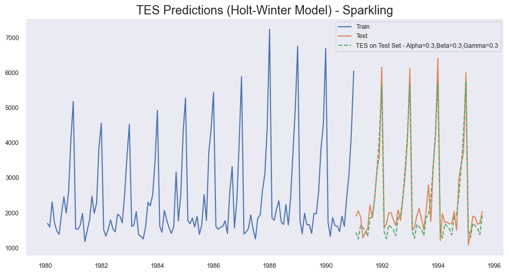

```python
## Plotting on both the Training and Test using autofit
plt.plot(TES_train['Sparkling'], label='Train')
plt.plot(TES_test['Sparkling'], label='Test')
plt.plot(TES_test['predict',0.3,0.3,0.3], linestyle='--', label='TES on Test Set - Alpha=0.3,Beta=0.3,Gamma=0.3')
plt.title('TES Predictions (Holt-Winter Model) - Sparkling', fontsize=17)

plt.legend(loc='best')
plt.grid();
```

### Stationarity Check on Training Dataset

```python
# Function to check staionarity
def test_stationarity(timeseries):

    #determining roll statistics
    rolmean = timeseries.rolling(window=12).mean()
    rolstd = timeseries.rolling(window=12).std()

    ##plot rolling Statistics:
    orig = plt.plot(timeseries,color='blue',label='Original')
    mean = plt.plot(rolmean, color='red', label='Rolling Mean')
    std = plt.plot(rolstd, color='black', label='Rolling Std')
    plt.legend(loc='best')
    plt.title('Rolling Mean and Standard Deviation', fontsize=17)
    plt.show(block=False)

    #Perform Dickey-Fuller Test:
    print('Results of Dickey Fuller Test:')
    dftest = adfuller(timeseries, autolag='AIC')
    dfoutput = pd.Series(dftest[0:4], index=['Test Statistic','p-value','#Lags Used','Number of Observations Used'])
    for key,value in dftest[4].items():
        dfoutput['Critical Value (%s)'%key] = value
    print(dfoutput,'\n')
```

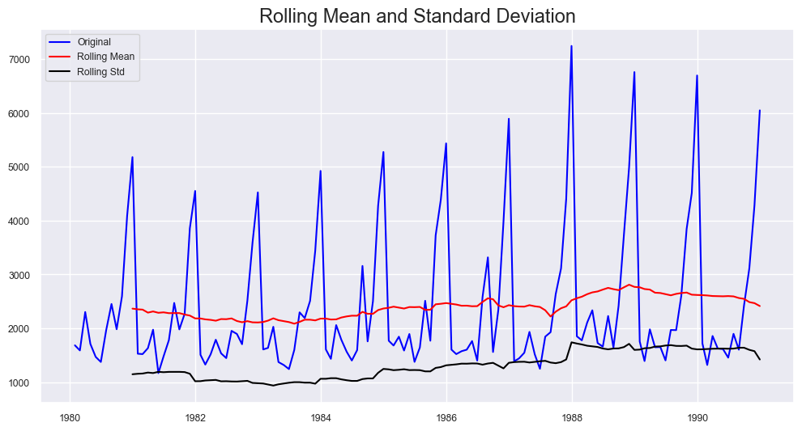

```
Results of Dickey Fuller Test:
Test Statistic                 -1.2089
p-value                         0.6697
#Lags Used                     12.0000
Number of Observations Used   119.0000
Critical Value (1%)            -3.4865
Critical Value (5%)            -2.8862
Critical Value (10%)           -2.5799
dtype: float64
```

```python
# Test stationarity on Sparkling training dataset
test_stationarity(train_dfs['Sparkling'])
```

**Hypothesis:**

H0 = Series is not stationary

H1 = Series is stationary

#### Observations:

- High p-value of 0.6697 fails to reject the null-hypothesis and confirms the Time Series is not Stationary.
- We will apply differncing in the next step in attempt to make the Time Series Stationary.

```python
# Apply Differencing on Training Dataset
train_dfs_diff = train_dfs.diff().dropna()
train_dfs_diff_test = adfuller(train_dfs_diff,regression='ct')
print(f'DF test statistics is: {train_dfs_diff_test[0]}')
print(f'DF test p-value is: {train_dfs_diff_test[1]}')
print(f'Number of lags used is: {train_dfs_diff_test[2]}')
if train_dfs_diff_test[1] <= 0.05:
    print('The Differenced Time Series is Stationary now.')
else:
    print('The Time Series is Not Stationary')
```

```
DF test statistics is: -7.967842196255539
DF test p-value is: 8.479210655514579e-11
Number of lags used is: 11
The Differenced Time Series is Stationary now.
```

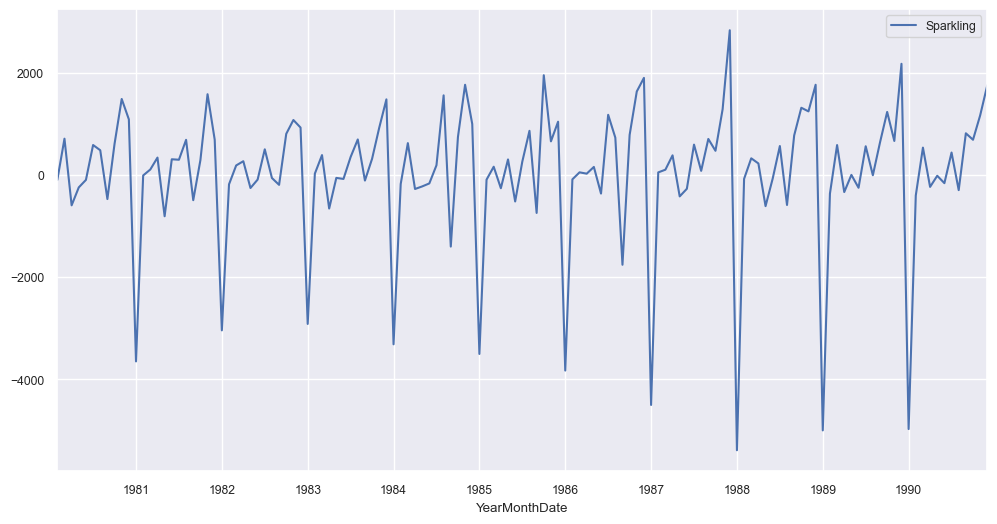

```python
# Plot the differenced time-series chart
train_dfs_diff.plot(grid=True);
```

#### Observations:

- Diffencing has made the time-series stationary.
- We will continue to peform ARIMA and SARIMA model building.

### Automated ARIMA model based on Lowest AIC

```python
# Define the p, d, q parameters to take any value between 0 and 3 for p and q, and 1 for d
p = q = range(0,4)
d = range(1,2)

# Generate all different combinations of p, d, and q triplets
pdq = list(itertools.product(p,d,q))

# Print the generated combinations of p, d, q
print('Examples of the parameter combinations for the models')
for i in range(0,len(pdq)):
    print(f'Model : {pdq[i]}')
```

```
Examples of the parameter combinations for the models
Model : (0, 1, 0)
Model : (0, 1, 1)
Model : (0, 1, 2)
Model : (0, 1, 3)
Model : (1, 1, 0)
Model : (1, 1, 1)
Model : (1, 1, 2)
Model : (1, 1, 3)
Model : (2, 1, 0)
Model : (2, 1, 1)
Model : (2, 1, 2)
Model : (2, 1, 3)
Model : (3, 1, 0)
Model : (3, 1, 1)
Model : (3, 1, 2)
Model : (3, 1, 3)
```

```python
# Creating an empty Dataframe with column names only for ARIMA
ARIMA_AIC = pd.DataFrame(columns=['param', 'AIC'])
ARIMA_AIC
```

|  | param | AIC |
| --- | --- | --- |

```python
# Appending the AIC values and the model parameters to the previously created data frame
counter = 0
for param in pdq: # running a loop within the pdq parameters defined by itertools
    ARIMA_model  =  ARIMA(train_dfs['Sparkling'].values, order=param).fit()
    # print(f'ARIMA{param} - AIC: {ARIMA_model.aic:.4f}')

    #printing the parameters and the AIC from the fitted models
    ARIMA_AIC.loc[counter] = [param,ARIMA_model.aic]
    counter += 1

# For easier understanding and sorting of the AIC values
print('AIC Values in ascending order')
ARIMA_AIC.sort_values(by='AIC',ascending=True).head()
```

```
AIC Values in ascending order
```

|  | param | AIC |
| --- | --- | --- |
| 10 | (2, 1, 2) | 2213.5092 |
| 15 | (3, 1, 3) | 2221.4549 |
| 14 | (3, 1, 2) | 2230.7806 |
| 11 | (2, 1, 3) | 2232.8840 |
| 9 | (2, 1, 1) | 2233.7776 |

```python
# lowest AIC achieved is 2213.5092, using parameters 2,1,2. We will develop Automated ARIMA model using this parameters.
auto_ARIMA = ARIMA(train_dfs, order=(2,1,2))
results_auto_ARIMA = auto_ARIMA.fit()
print(results_auto_ARIMA.summary())
```

```
                               SARIMAX Results
==============================================================================
Dep. Variable:              Sparkling   No. Observations:                  132
Model:                 ARIMA(2, 1, 2)   Log Likelihood               -1101.755
Date:                Sun, 04 Aug 2024   AIC                           2213.509
Time:                        16:55:13   BIC                           2227.885
Sample:                    01-31-1980   HQIC                          2219.351
                         - 12-31-1990
Covariance Type:                  opg
==============================================================================
                 coef    std err          z      P>|z|      [0.025      0.975]
------------------------------------------------------------------------------
ar.L1          1.3121      0.046     28.782      0.000       1.223       1.401
ar.L2         -0.5593      0.072     -7.741      0.000      -0.701      -0.418
ma.L1         -1.9917      0.109    -18.217      0.000      -2.206      -1.777
ma.L2          0.9999      0.110      9.109      0.000       0.785       1.215
sigma2      1.099e+06   1.99e-07   5.51e+12      0.000     1.1e+06     1.1e+06
===================================================================================
Ljung-Box (L1) (Q):                   0.19   Jarque-Bera (JB):                14.46
Prob(Q):                              0.67   Prob(JB):                         0.00
Heteroskedasticity (H):               2.43   Skew:                             0.61
Prob(H) (two-sided):                  0.00   Kurtosis:                         4.08
===================================================================================

Warnings:
[1] Covariance matrix calculated using the outer product of gradients (complex-step).
[2] Covariance matrix is singular or near-singular, with condition number 8.24e+27. Standard errors may be unstable.
```

#### Observations:

- All coefficients are statistically significant.
- The AR(1) term, with a z-score of 28.782, suggests strong positive autocorrelation.
- The MA(1) term, with a z-score of -18.217, indicates a significant negative influence of past forecast errors on the model.

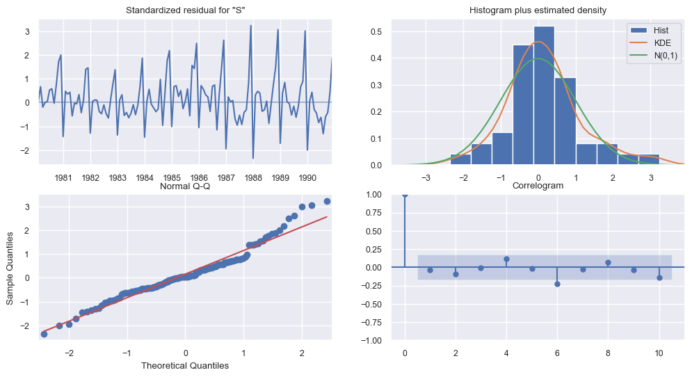

```python
# Plot Diagnostics
results_auto_ARIMA.plot_diagnostics();
```

#### Observations:

- The ARIMA(2, 1, 2) model appears to fit the data reasonably well. The residuals do not show significant autocorrelation, and they are approximately normally distributed.
- While the residuals are roughly normal, there are some deviations, particularly in the tails, which might need further investigation or model refinement.
- The residuals show minimal autocorrelation, indicating that the ARIMA model has successfully captured the underlying patterns in the time series data.

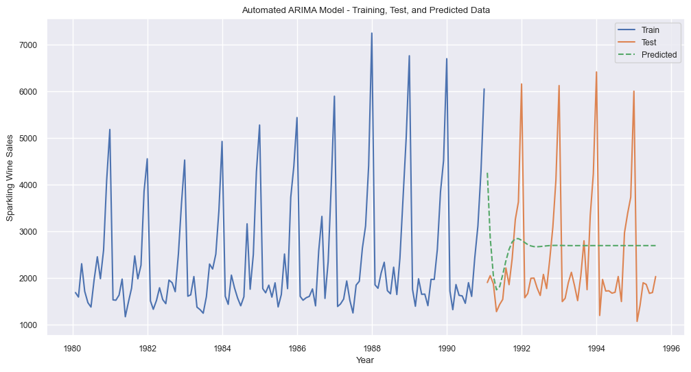

```python
# Predict values based on Automated ARIMA model
predicted_auto_ARIMA = results_auto_ARIMA.forecast(steps=len(test_dfs))

# Plot the train, test and predicted data.
plt.plot(train_dfs.index, train_dfs['Sparkling'], label='Train')
plt.plot(test_dfs.index, test_dfs['Sparkling'], label='Test')
plt.plot(test_dfs.index, predicted_auto_ARIMA, linestyle='--', label='Predicted')

plt.xlabel('Year')
plt.ylabel('Sparkling Wine Sales')
plt.title('Automated ARIMA Model - Training, Test, and Predicted Data')
plt.legend(loc='best')
plt.grid(True)

# Show the plot
plt.show()
```

```python
# Calculate Root Mean Squared Error for Automated ARIMA Model
rmse_ARIMA_test = metrics.mean_squared_error(test_dfs['Sparkling'],predicted_auto_ARIMA,squared=False)
print(f'For Automated ARIMA Model forecast on the Test Data,  RMSE is {rmse_ARIMA_test: .4f}')
```

```
For Automated ARIMA Model forecast on the Test Data,  RMSE is  1299.9800
```

```python
# Adding the new row to the DataFrame
resultsDf.loc['Automated ARIMA with params (p=2,d=1,q=2)'] = rmse_ARIMA_test
resultsDf
```

|  | Test RMSE |
| --- | --- |
| Linear Regression | 1389.1352 |
| Naive Model | 3864.2794 |
| Simple Average Model | 1275.0818 |
| SES with Alpha=0.0395 | 1304.9274 |
| Tuned SES with Alpha=0.3 | 1935.5071 |
| DES with Alpha=0.668 and Beta=9.99e-05 | 2007.2385 |
| Tuned DES with Alpha=0.3 and Beta=0.3 | 18259.1107 |
| TES with Alpha=0.1111,Beta=0.0494,Gamma=0.3621 | 404.2868 |
| Tuned TES with Alpha=0.3,Beta=0.3,Gamma=0.3 | 361.3973 |
| Automated ARIMA with params (p=2,d=1,q=2) | 1299.9800 |

### Automated SARIMA Model based on lowest AIC

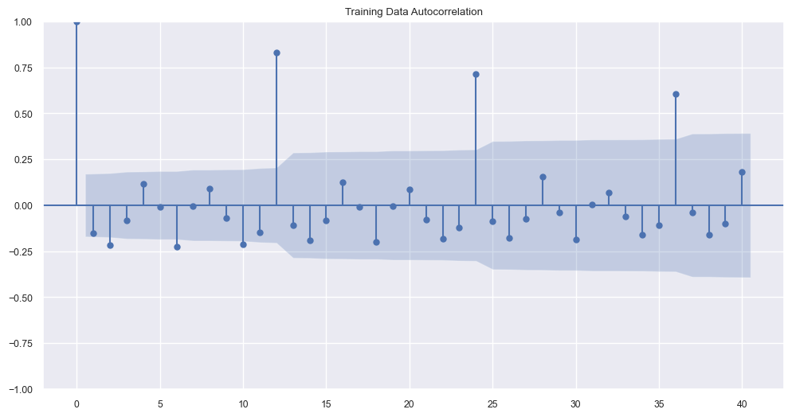

```python
# Plot Autocorrelation Plot
plot_acf(train_dfs.diff(),title='Training Data Autocorrelation',missing='drop',lags=40);
```

```python
# Define the range for p, d, q parameters for the ARIMA part of SARIMA
p = q = range(0, 4)
d= range(1,2)

# Define the range for P, D, Q parameters for the seasonal part of SARIMA
D = range(0,1)

# Generate all possible combinations of p, d, q
pdq = list(itertools.product(p, d, q))

# Generate all possible combinations of P, D, Q with a seasonal period (m) of 12
seasonal_pdq = [(x[0], x[1], x[2], 12) for x in list(itertools.product(p, D, q))]

# Print examples of the parameter combinations for the SARIMA model
print('Examples of the parameter combinations for the Model are:')
for i in range(1,len(pdq)):
    print(f'Model: {pdq[i]}{seasonal_pdq[i]}')
```

```
Examples of the parameter combinations for the Model are:
Model: (0, 1, 1)(0, 0, 1, 12)
Model: (0, 1, 2)(0, 0, 2, 12)
Model: (0, 1, 3)(0, 0, 3, 12)
Model: (1, 1, 0)(1, 0, 0, 12)
Model: (1, 1, 1)(1, 0, 1, 12)
Model: (1, 1, 2)(1, 0, 2, 12)
Model: (1, 1, 3)(1, 0, 3, 12)
Model: (2, 1, 0)(2, 0, 0, 12)
Model: (2, 1, 1)(2, 0, 1, 12)
Model: (2, 1, 2)(2, 0, 2, 12)
Model: (2, 1, 3)(2, 0, 3, 12)
Model: (3, 1, 0)(3, 0, 0, 12)
Model: (3, 1, 1)(3, 0, 1, 12)
Model: (3, 1, 2)(3, 0, 2, 12)
Model: (3, 1, 3)(3, 0, 3, 12)
```

```python
# Create Empty Dataframe to store parameters, seasonal parameters and AIC
SARIMA_AIC = pd.DataFrame(columns=['param','seasonal', 'AIC'])
SARIMA_AIC
```

|  | param | seasonal | AIC |
| --- | --- | --- | --- |

```python
# Generate AIC for each parameters
counter = 0

# Loop through each combination of pdq and seasonal_pdq
for param in pdq:
    for param_seasonal in seasonal_pdq:
        # Create the SARIMA model with the current parameter combination
        SARIMA_model = sm.tsa.statespace.SARIMAX(train_dfs['Sparkling'].values,
                                            order=param,
                                            seasonal_order=param_seasonal,
                                            enforce_stationarity=False,
                                            enforce_invertibility=False)

        # Fit the SARIMA model
        results_SARIMA = SARIMA_model.fit(maxiter=1000)

        # Store the AIC value along with the parameters in the DataFrame
        SARIMA_AIC.loc[counter] = [param,param_seasonal,results_SARIMA.aic]
        counter += 1

# Sort the DataFrame by AIC values in ascending order and display top 5 results
SARIMA_AIC.sort_values(by='AIC',ascending=True).head()
```

|  | param | seasonal | AIC |
| --- | --- | --- | --- |
| 252 | (3, 1, 3) | (3, 0, 0, 12) | 1387.4970 |
| 220 | (3, 1, 1) | (3, 0, 0, 12) | 1387.7883 |
| 237 | (3, 1, 2) | (3, 0, 1, 12) | 1388.6026 |
| 221 | (3, 1, 1) | (3, 0, 1, 12) | 1388.6815 |
| 222 | (3, 1, 1) | (3, 0, 2, 12) | 1389.1959 |

```python
# Build Auto SARIMA model using the parameters that gave lowest AIC of 1387.4970
auto_SARIMA = sm.tsa.statespace.SARIMAX(train_dfs['Sparkling'],order=(3,1,3),seasonal_order=(3,0,0,12),enforce_stationarity=False,
                                       enforce_invertibility=False)
results_auto_SARIMA = auto_SARIMA.fit(maxiter=1000)
print(results_auto_SARIMA.summary())
```

```
                                      SARIMAX Results
===========================================================================================
Dep. Variable:                           Sparkling   No. Observations:                  132
Model:             SARIMAX(3, 1, 3)x(3, 0, [], 12)   Log Likelihood                -683.749
Date:                             Sun, 04 Aug 2024   AIC                           1387.497
Time:                                     17:07:09   BIC                           1412.715
Sample:                                 01-31-1980   HQIC                          1397.675
                                      - 12-31-1990
Covariance Type:                               opg
==============================================================================
                 coef    std err          z      P>|z|      [0.025      0.975]
------------------------------------------------------------------------------
ar.L1         -1.6746      0.142    -11.814      0.000      -1.952      -1.397
ar.L2         -0.7435      0.258     -2.885      0.004      -1.249      -0.238
ar.L3         -0.0022      0.144     -0.015      0.988      -0.285       0.280
ma.L1          1.0548      0.191      5.511      0.000       0.680       1.430
ma.L2         -0.7783      0.172     -4.523      0.000      -1.116      -0.441
ma.L3         -0.9065      0.148     -6.141      0.000      -1.196      -0.617
ar.S.L12       0.5329      0.118      4.523      0.000       0.302       0.764
ar.S.L24       0.2789      0.116      2.403      0.016       0.051       0.506
ar.S.L36       0.2388      0.102      2.349      0.019       0.040       0.438
sigma2      1.527e+05   1.94e-06   7.89e+10      0.000    1.53e+05    1.53e+05
===================================================================================
Ljung-Box (L1) (Q):                   0.01   Jarque-Bera (JB):                 4.32
Prob(Q):                              0.93   Prob(JB):                         0.12
Heteroskedasticity (H):               1.26   Skew:                             0.30
Prob(H) (two-sided):                  0.52   Kurtosis:                         3.88
===================================================================================

Warnings:
[1] Covariance matrix calculated using the outer product of gradients (complex-step).
[2] Covariance matrix is singular or near-singular, with condition number 8.51e+26. Standard errors may be unstable.
```

#### Observations:

- Most AR and MA terms are highly significant, except for the AR(3) term, which is not significant.
- Residuals are uncorrelated, approximately normally distributed (Jarque-Bera test), and homoscedastic.
- Seasonal terms (AR(12), AR(24), AR(36)) are significant, indicating the importance of seasonal components in the model.

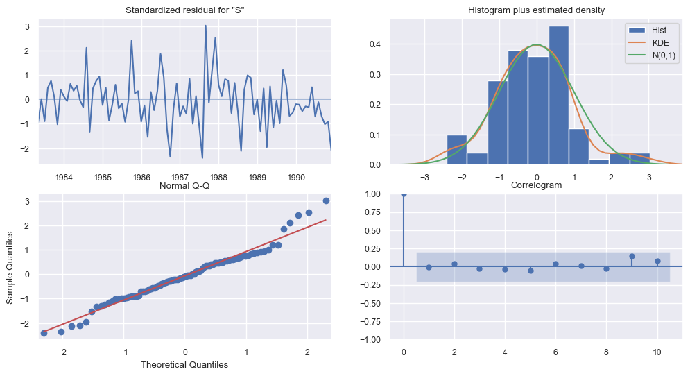

```python
# Diagnostic Plot
results_auto_SARIMA.plot_diagnostics();
```

#### Observations:

- Residuals fluctuate around zero, indicating a good fit, but with some spikes suggesting potential outliers.
- Histogram and Q-Q plot show residuals are approximately normally distributed, with slight deviations in the tails.
- Correlogram indicates residuals are largely uncorrelated, suggesting the model captures the underlying patterns well.

```python
# Predict on the Test Set using the fitted SARIMA model
predicted_auto_SARIMA = results_auto_SARIMA.get_forecast(steps=len(test_dfs))

# Get a summary frame of the forecast, including the confidence intervals
# alpha=0.05 corresponds to a 95% confidence interval
forecast_summary = predicted_auto_SARIMA.summary_frame(alpha=0.05)

# Display the first few rows of the forecast summary to evaluate the model's predictions
forecast_summary.head()
```

| Sparkling | mean | mean_se | mean_ci_lower | mean_ci_upper |
| --- | --- | --- | --- | --- |
| 1991-01-31 | 1342.0687 | 394.7649 | 568.3437 | 2115.7937 |
| 1991-02-28 | 1350.6448 | 419.5479 | 528.3460 | 2172.9436 |
| 1991-03-31 | 1578.4924 | 421.1172 | 753.1178 | 2403.8671 |
| 1991-04-30 | 1667.7383 | 432.6240 | 819.8108 | 2515.6658 |
| 1991-05-31 | 1320.6283 | 432.6576 | 472.6350 | 2168.6216 |

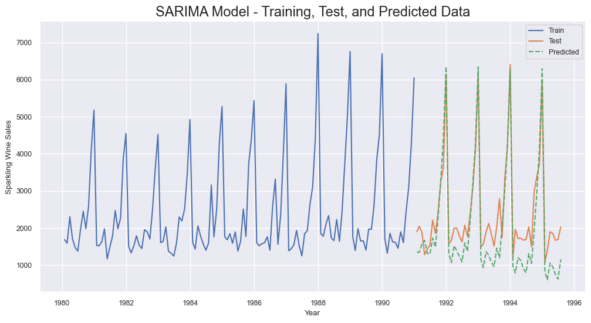

```python
# Plot the training data, test data, and predicted values
plt.plot(train_dfs.index, train_dfs['Sparkling'], label='Train')
plt.plot(test_dfs.index, test_dfs['Sparkling'], label='Test')
plt.plot(predicted_auto_SARIMA.predicted_mean.index, predicted_auto_SARIMA.predicted_mean, linestyle='--', label='Predicted')

# Add labels, title, legend, and grid
plt.xlabel('Year')
plt.ylabel('Sparkling Wine Sales')
plt.title('SARIMA Model - Training, Test, and Predicted Data', fontsize=17)
plt.legend(loc='best')
plt.grid(True)

# Show the plot
plt.show()
```

```python
# Calculate Root Mean Squared Error for Automated SARIMA Model
rmse_SARIMA_test = metrics.mean_squared_error(test_dfs['Sparkling'],predicted_auto_SARIMA.predicted_mean,squared=False)
print(f'For Automated SARIMA Model forecast on the Test Data,  RMSE is {rmse_SARIMA_test: .4f}')
```

```
For Automated SARIMA Model forecast on the Test Data,  RMSE is  611.1517
```

```python
# Adding the new row to the DataFrame
resultsDf.loc['Automated SARIMA with order = (3,1,3) and seasonal_order = (3,0,0,12)'] = rmse_SARIMA_test
resultsDf
```

|  | Test RMSE |
| --- | --- |
| Linear Regression | 1389.1352 |
| Naive Model | 3864.2794 |
| Simple Average Model | 1275.0818 |
| SES with Alpha=0.0395 | 1304.9274 |
| Tuned SES with Alpha=0.3 | 1935.5071 |
| DES with Alpha=0.668 and Beta=9.99e-05 | 2007.2385 |
| Tuned DES with Alpha=0.3 and Beta=0.3 | 18259.1107 |
| TES with Alpha=0.1111,Beta=0.0494,Gamma=0.3621 | 404.2868 |
| Tuned TES with Alpha=0.3,Beta=0.3,Gamma=0.3 | 361.3973 |
| Automated ARIMA with params (p=2,d=1,q=2) | 1299.9800 |
| Automated SARIMA with order = (3,1,3) and seasonal_order = (3,0,0,12) | 611.1517 |

#### Observations:

- With seasonality component the SARIMA model shows good RMSE of 611.15 (rounded).
- We will now compare each mode before deciding on the final model for forecasting.

## Model Comparison and Final Model Selection

```python
# Display Test RMSE of each mode in ascending order
resultsDf['Test RMSE'] = resultsDf['Test RMSE'].astype(float) #change the datatype to float
resultsDf.sort_values(by='Test RMSE',ascending=True)
```

|  | Test RMSE |
| --- | --- |
| Tuned TES with Alpha=0.3,Beta=0.3,Gamma=0.3 | 361.3973 |
| TES with Alpha=0.1111,Beta=0.0494,Gamma=0.3621 | 404.2868 |
| Automated SARIMA with order = (3,1,3) and seasonal_order = (3,0,0,12) | 611.1517 |
| Simple Average Model | 1275.0818 |
| Automated ARIMA with params (p=2,d=1,q=2) | 1299.9800 |
| SES with Alpha=0.0395 | 1304.9274 |
| Linear Regression | 1389.1352 |
| Tuned SES with Alpha=0.3 | 1935.5071 |
| DES with Alpha=0.668 and Beta=9.99e-05 | 2007.2385 |
| Naive Model | 3864.2794 |
| Tuned DES with Alpha=0.3 and Beta=0.3 | 18259.1107 |

#### Observations:

- Tuned Tripple Exponential Smoothing model shows best RMSE of 361.3973 across the 11 models tested.
- We will use Tuned TES as final model to predict the values for next 12 monhts starting 1-Aug-1995.

## Forecasting using Final Model

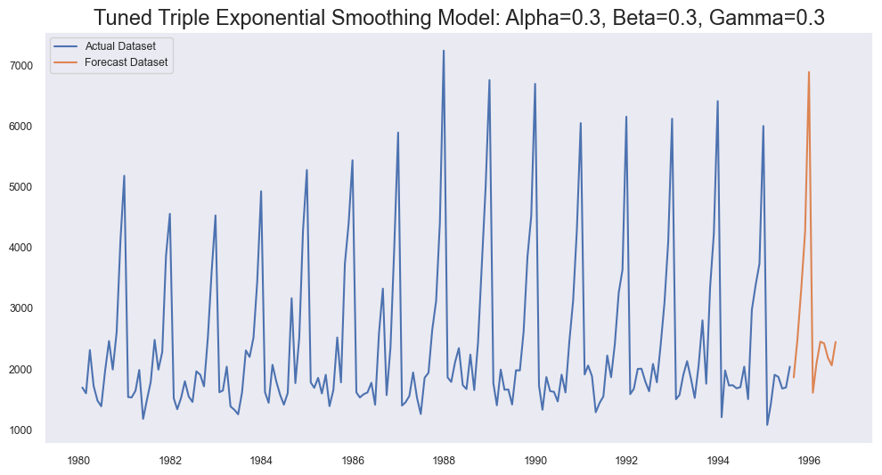

```python
# Getting forecast for next 12 months using Tuned TES mode with level = 0.3, Trend = 0.3 and Seasonal = 0.3
final_model = ExponentialSmoothing(df_sparkling_sales['Sparkling'],trend='additive',seasonal='multiplicative',freq='M')

# fit model
final_model_fit = final_model.fit(smoothing_level=0.3,smoothing_trend=0.3,smoothing_seasonal=0.3,optimized=False,use_brute=True)

# make prediction
forecast_value = final_model_fit.forecast(steps=12)

# Plot chart
plt.plot(df_sparkling_sales['Sparkling'], label='Actual Dataset')
plt.plot(forecast_value,label='Forecast Dataset')
plt.title('Tuned Triple Exponential Smoothing Model: Alpha=0.3, Beta=0.3, Gamma=0.3', fontsize=17)
plt.legend(loc='best')
plt.grid();
```

```python
print('Forecast values using Tuned TES Model:')
forecast_value
```

```
Forecast values using Tuned TES Model:
```

```
1995-08-31   1854.6863
1995-09-30   2490.9861
1995-10-31   3339.2051
1995-11-30   4256.1308
1995-12-31   6889.4122
1996-01-31   1600.6854
1996-02-29   2083.3658
1996-03-31   2443.1737
1996-04-30   2413.9502
1996-05-31   2176.3318
1996-06-30   2052.6619
1996-07-31   2438.5849
Freq: ME, dtype: float64
```

#### Calculate Forecast with 95% Confidernce Internval

```python
# Calculate the standard deviation of the residuals from the fitted model
residual_std = np.std(final_model_fit.resid, ddof=1)

# Create a DataFrame for the forecast values and their confidence intervals
pred_1_df = pd.DataFrame({
    'lower_CI': forecast_value - 1.96 * residual_std,  # Lower confidence interval (95%)
    'prediction': forecast_value,                      # Forecasted values
    'upper_CI': forecast_value + 1.96 * residual_std   # Upper confidence interval (95%)
})

# Display the first few rows of the DataFrame to verify
pred_1_df.head(12)
```

|  | lower_CI | prediction | upper_CI |
| --- | --- | --- | --- |
| 1995-08-31 | 1014.0693 | 1854.6863 | 2695.3033 |
| 1995-09-30 | 1650.3691 | 2490.9861 | 3331.6031 |
| 1995-10-31 | 2498.5881 | 3339.2051 | 4179.8221 |
| 1995-11-30 | 3415.5138 | 4256.1308 | 5096.7478 |
| 1995-12-31 | 6048.7952 | 6889.4122 | 7730.0291 |
| 1996-01-31 | 760.0684 | 1600.6854 | 2441.3024 |
| 1996-02-29 | 1242.7488 | 2083.3658 | 2923.9828 |
| 1996-03-31 | 1602.5568 | 2443.1737 | 3283.7907 |
| 1996-04-30 | 1573.3332 | 2413.9502 | 3254.5672 |
| 1996-05-31 | 1335.7149 | 2176.3318 | 3016.9488 |
| 1996-06-30 | 1212.0450 | 2052.6619 | 2893.2789 |
| 1996-07-31 | 1597.9679 | 2438.5849 | 3279.2019 |

#### Plot the predicted values along with confiential internval

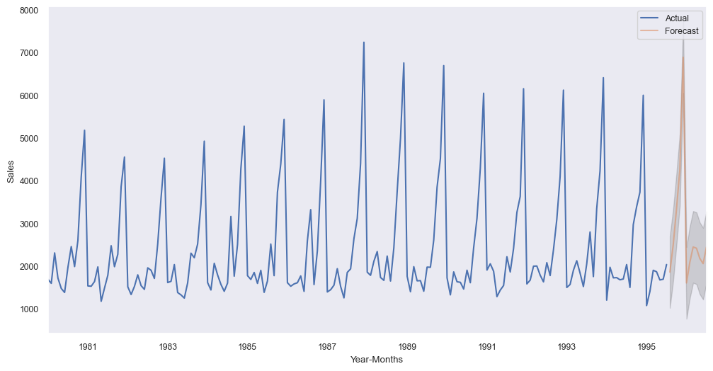

```python
# Plot the actual data
axis = df_sparkling_sales['Sparkling'].plot(label='Actual')

# Plot the forecasted values
pred_1_df['prediction'].plot(ax=axis, label='Forecast', alpha=0.5)

# Plot the confidence interval band
axis.fill_between(pred_1_df.index, pred_1_df['lower_CI'], pred_1_df['upper_CI'], color='k', alpha=0.15)

# Set the labels and title
axis.set_xlabel('Year-Months')
axis.set_ylabel('Sales')

# Add a legend to the plot
plt.legend(loc='best')

# Display grid lines for better readability
plt.grid()

# Show the plot
plt.show()
```

## Business Insights and Recommendations

- Actionable Insights
- Business Recommendations

### Actionable Insights:

**Dataset Overview:**

- The dataset consists of monthly sales data for sparkling wine from January 1980 to July 1995.
- Summary statistics show an average monthly sales of around 2,000 units with noticeable seasonal peaks.

**Data Quality:**

- There were no duplicate or missing values, which facilitated smooth model development and analysis.

**Seasonal and Trend Patterns:**

- Yearly and monthly analyses reveal consistent seasonal patterns, with sales peaking in December and lower sales observed in mid-year months.
- Although there was no clear year on year trend, sales seems to have gradually risen between 1982 till 1987 than started falling across most months.
- These patterns were effectively captured by the Triple Exponential Smoothing model, underscoring its suitability for this dataset.

**Model Performance:**

- The final model selected was the Tuned Triple Exponential Smoothing (TES) model with parameters Alpha=0.3, Beta=0.3, and Gamma=0.3. This model achieved the lowest RMSE of 361.3973, indicating superior accuracy.
- Automated TES and Automated SARIMA models also showed reasonably good performance with RMSE of 404.2868 and 611.1517 respectively. With further tuning these models can be improved.

### Business Recommendations:

**Adopt the Tuned TES Model:**

- Implement the Tuned Triple Exponential Smoothing (TES) model with parameters Alpha=0.3, Beta=0.3, and Gamma=0.3 for future sales forecasting due to its superior accuracy.

**Inventory Managemnt:**

- Forecast Sales derived from the Tuned TES model suggest boost of sales during last quarter. Use forecast to optimize inventory levels, ensuring adequate stock during peak demand periods while minimizing overstock during low-demand months.
- Align resource allocation, including staffing and logistics, with forecasted sales patterns to improve operational efficiency.

**Promotional Strategies:**

- Plan marketing and promotional activities around forecasted sales peaks to maximize their impact.Use insights from the model to schedule promotions during anticipated low-demand periods to boost sales.

**Further Model Enhancement:**

- Regularly update the model with new sales data to maintain and improve forecast accuracy.
- Explore incorporating additional variables, such as economic indicators or promotional event data, to enhance the model’s predictive capabilities.

**Continuous Monitoring:**

- Monitor the performance of the TES model regularly and adjust the parameters as needed based on changes in sales patterns or external factors.
- Perform periodic reviews of the forecast accuracy and make necessary adjustments to ensure continued reliability.

**Market Expansion Analysis:**

- Use the forecasting model to simulate potential sales in new markets or demographics, aiding in strategic market expansion decisions.
- Analyze customer purchasing behavior insights provided by the model to tailor engagement strategies and increase customer loyalty.

**Investigate Outliers:**

- Analyze periods with significant residual spikes to identify underlying causes, such as unexpected events or promotions, and adjust future forecasts accordingly.
- Use this analysis to improve model accuracy and incorporate such factors into future forecasts.